# GBM_pc2

```python
import numpy as np # linear algebra
import pandas as pd # data processing, CSV file I/O (e.g. pd.read_csv)
from sklearn.preprocessing import Imputer
from sklearn.preprocessing import StandardScaler

import seaborn as sns
import matplotlib.pyplot as plt
%matplotlib inline

from collections import Counter
from sklearn.ensemble import GradientBoostingClassifier
from sklearn.model_selection import GridSearchCV, cross_val_score, StratifiedKFold, learning_curve
import time

sns.set(style='white', context='notebook', palette='deep')
# Input data files are available in the "../input/" directory.
# For example, running this (by clicking run or pressing Shift+Enter) will list the files in the input directory
```

```python
train=pd.read_csv('../input/train.csv')
test=pd.read_csv('../input/test.csv')
```

```python
features_not_using_calc = [feature for feature in train.columns if 'ps_calc_' in feature and feature not in ['ps_calc_06', 'ps_calc_07', 'ps_calc_11', 'ps_calc_12', 'ps_calc_10']]
```

```python
features_not_using_bin = ['ps_ind_10_bin', 'ps_ind_11_bin', 'ps_ind_12_bin', 'ps_ind_13_bin']
```

```python
feature_not_using_total = features_not_using_bin + features_not_using_calc
```

```python
feature_not_using_total
```

```
['ps_ind_10_bin',
 'ps_ind_11_bin',
 'ps_ind_12_bin',
 'ps_ind_13_bin',
 'ps_calc_01',
 'ps_calc_02',
 'ps_calc_03',
 'ps_calc_04',
 'ps_calc_05',
 'ps_calc_08',
 'ps_calc_09',
 'ps_calc_13',
 'ps_calc_14',
 'ps_calc_15_bin',
 'ps_calc_16_bin',
 'ps_calc_17_bin',
 'ps_calc_18_bin',
 'ps_calc_19_bin',
 'ps_calc_20_bin']
```

```python
train.drop(feature_not_using_total, inplace=True, axis=1)
test.drop(feature_not_using_total, inplace=True, axis=1)
print(train.drop('target', axis=1).columns == test.columns)
```

```
[ True  True  True  True  True  True  True  True  True  True  True  True
  True  True  True  True  True  True  True  True  True  True  True  True
  True  True  True  True  True  True  True  True  True  True  True  True
  True  True  True]
```

```python
train.shape
```

```
(595212, 40)
```

```python
meta
```

[output not shown]

```python
data = []
for feature in train.columns:
    # Defining the role
    if feature == 'target':
        role = 'target'
    elif feature == 'id':
        role = 'id'
    else:
        role = 'input'

    # Defining the level
    if 'bin' in feature or feature == 'target':
        level = 'binary'
    elif 'cat' in feature or feature == 'id':
        level = 'nominal'
    elif train[feature].dtype == float:
        level = 'interval'
    elif train[feature].dtype == int:
        level = 'ordinal'

    # Initialize keep to True for all variables except for id
    keep = True
    if feature == 'id':
        keep = False

    # Defining the data type
    dtype = train[feature].dtype

    # Creating a Dict that contains all the metadata for the  variable
    f_dict = {
        'varname' : feature,
        'role': role,
        'level': level,
        'keep': keep,
        'dtype': dtype
    }
    data.append(f_dict)
```

```python
meta = pd.DataFrame(data, columns=['varname', 'role', 'level', 'keep', 'dtype'])
meta.set_index('varname', inplace=True)
```

```python
# Imputing with the mean or mode
mean_imp = Imputer(missing_values=-1, strategy='mean', axis=0) # pandas 에서 axis=0 는 아래위, axis=1 은 좌우로. concat은 axis=1 하는 거 생각.
mode_imp = Imputer(missing_values=-1, strategy='most_frequent', axis=0)
train['ps_reg_03'] = mean_imp.fit_transform(train[['ps_reg_03']]).ravel()
train['ps_car_12'] = mean_imp.fit_transform(train[['ps_car_12']]).ravel()
train['ps_car_14'] = mean_imp.fit_transform(train[['ps_car_14']]).ravel()
train['ps_car_11'] = mode_imp.fit_transform(train[['ps_car_11']]).ravel()

test['ps_reg_03'] = mean_imp.fit_transform(test[['ps_reg_03']]).ravel()
test['ps_car_12'] = mean_imp.fit_transform(test[['ps_car_12']]).ravel()
test['ps_car_14'] = mean_imp.fit_transform(test[['ps_car_14']]).ravel()
test['ps_car_11'] = mode_imp.fit_transform(test[['ps_car_11']]).ravel()
```

PCA part

```python
# X_train = train[['ps_ind_04_cat', 'ps_car_11_cat']]
# pca = PCA(n_components=2)
# pca.fit(X_train)
# X_pca = pca.transform(X_train)
# pca_label = ['{}_{}_{}'.format('ps_ind_04_cat', 'ps_car_11_cat', i) for i in range(2)]
# d = {pca_label[1]: X_pca[:, 1], pca_label[0]: X_pca[:, 0]}
# df = pd.DataFrame(data=d, columns=[pca_label[1], pca_label[0]])
# train = pd.concat([train, df], axis=1)
# # train.drop(['ps_ind_04_cat', 'ps_car_11_cat'], axis=1, inplace=True)
```

```python
# X_test = test[['ps_ind_04_cat', 'ps_car_11_cat']]
# X_test_pca = pca.transform(X_test)
# pca_label = ['{}_{}_{}'.format('ps_ind_04_cat', 'ps_car_11_cat', i) for i in range(2)]
# d = {pca_label[1]: X_test_pca[:, 1], pca_label[0]: X_test_pca[:, 0]}
# df = pd.DataFrame(data=d, columns=[pca_label[1], pca_label[0]])
# test = pd.concat([test, df], axis=1)
# # test.drop(['ps_ind_04_cat', 'ps_car_11_cat'], axis=1, inplace=True)
# print(train.drop('target', axis=1).columns == test.columns)
```

Scaling part

```python
# # scaling
# for feature in meta[(meta['level'] == 'interval') & (meta.keep == True)].index:
#     scaler = StandardScaler()
#     x_train_before = train[feature].reshape(-1, 1)
#     scaler.fit(x_train_before)
#     x_train_scaled = scaler.transform(x_train_before)
#     train[feature] = x_train_scaled

#     x_test_before = test[feature].reshape(-1, 1)
#     x_test_scaled = scaler.transform(x_test_before)
#     test[feature] = x_test_scaled
# print(train.drop('target', axis=1).columns == test.columns)
```

```python
train.replace(-1, 1989, inplace=True)
test.replace(-1, 1989, inplace=True)
```

```python
def kinetic(row):
    probs = np.unique(row, return_counts=True)[1]/len(row)
    kinetic = np.sum(probs**2)
    return kinetic
```

```python
first_kin_names = [col for col in train.columns if '_ind_' in col]
subset_ind = train[first_kin_names]
kinetic_1=[]
for row in range(subset_ind.shape[0]):
    row = subset_ind.iloc[row]
    k = kinetic(row)
    kinetic_1.append(k)
```

같은 수의 cardinality 를 가진 feature 끼리 하는게 낫지 않겠나??

```python
second_kin_names = [col for col in train.columns if '_car_' in col and col.endswith('cat')]
subset_ind = train[second_kin_names]
kinetic_2 = []
for row in range(subset_ind.shape[0]):
    row = subset_ind.iloc[row]
    k = kinetic(row)
    kinetic_2.append(k)
```

```python
third_kin_names = [col for col in train.columns if '_calc_' in col and not col.endswith('bin')]
subset_ind = train[third_kin_names]
kinetic_3=[]
for row in range(subset_ind.shape[0]):
    row = subset_ind.iloc[row]
    k = kinetic(row)
    kinetic_3.append(k)
```

```python
fd_kin_names= [col for  col in train.columns  if '_calc_' in col and  col.endswith('bin')]
subset_ind = train[fd_kin_names]
kinetic_4 = []
for row in range(subset_ind.shape[0]):
    row = subset_ind.iloc[row]
    k = kinetic(row)
    kinetic_4.append(k)
```

```python
train['kinetic_1'] = np.array(kinetic_1)
train['kinetic_2'] = np.array(kinetic_2)
train['kinetic_3'] = np.array(kinetic_3)
train['kinetic_4'] = np.array(kinetic_4)
```

```python
first_kin_names = [col for col in test.columns if '_ind_' in col]
subset_ind = test[first_kin_names]
kinetic_1=[]
for row in range(subset_ind.shape[0]):
    row = subset_ind.iloc[row]
    k = kinetic(row)
    kinetic_1.append(k)
```

```python
second_kin_names = [col for col in test.columns if '_car_' in col and col.endswith('cat')]
subset_ind = test[second_kin_names]
kinetic_2 = []
for row in range(subset_ind.shape[0]):
    row = subset_ind.iloc[row]
    k = kinetic(row)
    kinetic_2.append(k)
```

```python
third_kin_names = [col for col in test.columns if '_calc_' in col and not col.endswith('bin')]
subset_ind = test[third_kin_names]
kinetic_3=[]
for row in range(subset_ind.shape[0]):
    row = subset_ind.iloc[row]
    k = kinetic(row)
    kinetic_3.append(k)
```

```python
fd_kin_names= [col for  col in test.columns  if '_calc_' in col and  col.endswith('bin')]
subset_ind = test[fd_kin_names]
kinetic_4 = []
for row in range(subset_ind.shape[0]):
    row = subset_ind.iloc[row]
    k = kinetic(row)
    kinetic_4.append(k)
```

```python
test['kinetic_1']=np.array(kinetic_1)
test['kinetic_2']=np.array(kinetic_2)
test['kinetic_3']=np.array(kinetic_3)
test['kinetic_4']=np.array(kinetic_4)
```

One-hot encoding part

```python
train.columns
```

```
Index(['id', 'target', 'ps_ind_01', 'ps_ind_02_cat', 'ps_ind_03',
       'ps_ind_04_cat', 'ps_ind_05_cat', 'ps_ind_06_bin', 'ps_ind_07_bin',
       'ps_ind_08_bin', 'ps_ind_09_bin', 'ps_ind_14', 'ps_ind_15',
       'ps_ind_16_bin', 'ps_ind_17_bin', 'ps_ind_18_bin', 'ps_reg_01',
       'ps_reg_02', 'ps_reg_03', 'ps_car_01_cat', 'ps_car_02_cat',
       'ps_car_03_cat', 'ps_car_04_cat', 'ps_car_05_cat', 'ps_car_06_cat',
       'ps_car_07_cat', 'ps_car_08_cat', 'ps_car_09_cat', 'ps_car_10_cat',
       'ps_car_11_cat', 'ps_car_11', 'ps_car_12', 'ps_car_13', 'ps_car_14',
       'ps_car_15', 'ps_calc_06', 'ps_calc_07', 'ps_calc_10', 'ps_calc_11',
       'ps_calc_12', 'kinetic_1', 'kinetic_2', 'kinetic_3', 'kinetic_4'],
      dtype='object')
```

```python
meta.loc[meta.index == 'ps_car_11_cat', 'keep'] = False
```

```python
train.drop(['ps_car_11_cat'], axis=1, inplace=True)
test.drop(['ps_car_11_cat'], axis=1, inplace=True)
```

```python
v = meta[(meta.level == 'nominal') & (meta.keep)].index
train = pd.get_dummies(train, columns=v, drop_first=True)
test = pd.get_dummies(test, columns=v, drop_first=True)
print(train.drop('target', axis=1).columns == test.columns)
```

```
[ True  True  True  True  True  True  True  True  True  True  True  True
  True  True  True  True  True  True  True  True  True  True  True  True
  True  True  True  True  True  True  True  True  True  True  True  True
  True  True  True  True  True  True  True  True  True  True  True  True
  True  True  True  True  True  True  True  True  True  True  True  True
  True  True  True  True  True  True  True  True  True  True  True  True
  True  True  True  True  True  True  True  True  True  True  True  True
  True  True  True  True  True  True  True  True  True  True  True  True]
```

```python
train.shape
```

```
(595212, 97)
```

```python
# import xgboost as xgb
# import lightgbm as lgb
# # from multiprocessing import *
```

```python
d_median = train.median(axis=0)
d_mean = train.mean(axis=0)
# axis=0 일때 계산은, column 으로 계산. 붙이는것도 위아래, 계산도 위아래
# axis=1 일때 게산은, row 로 계산. 붙이는 것도 좌우, 계산도 좌우.
```

```python
def transform_df(df):
    df = pd.DataFrame(df)
    dcol = [c for c in df.columns if c not in ['id', 'target']]
    df['ps_car_13_x_ps_reg_03'] = df['ps_car_13'] * df['ps_reg_03']
#     for c in dcol:
#         if '_bin' not in c:
#             df[c+str('_median_range')] = (df[c].values > d_median[c]).astype(int)
#             df[c+str('_mean_range')] = (df[c].values > d_mean[c]).astype(int)
    return df
```

```python
def multi_transform(df):
    print('Init Shape: ', df.shape)
    p = Pool(cpu_count())
    df = p.map(transform_df, np.array_split(df, cpu_count()))
    df = pd.concat(df, axis=0, ignore_index=True).reset_index(drop=True)
    p.close(); p.join()
    print('After Shape: ', df.shape)
    return df
```

```python
def gini(y, pred):
    g = np.asarray(np.c_[y, pred, np.arange(len(y)) ], dtype=np.float)
    g = g[np.lexsort((g[:,2], -1*g[:,1]))]
    gs = g[:,0].cumsum().sum() / g[:,0].sum()
    gs -= (len(y) + 1) / 2.
    return gs / len(y)

def normalized_gini(pred, y):
    return gini(y, pred) / gini(y, y)

def gini_xgb(pred, y):
    y = y.get_label()
    return 'gini', gini(y, pred) / gini(y, y)

def gini_lgb(preds, dtrain):
    y = list(dtrain.get_label())
    score = gini(y, preds) / gini(y, y)
    return 'gini', score, True
```

```python
len(train.columns)
```

```
97
```

```python
train = transform_df(train)
test = transform_df(test)
```

```python
len(train.columns)
```

```
98
```

```python
x_train = train.drop(['id', 'target'], axis=1)
y_train = train['target']
x_test = test.drop(['id'], axis=1)
features = x_train.columns
sub=test['id'].to_frame()
sub['target']=0
```

```python
# Cross validate model with Kfold stratified cross val
kfold = StratifiedKFold(n_splits=3)
```

[output not shown]

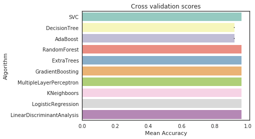

```python
random_state = 1989
classifiers = []
classifiers.append(SVC(random_state=random_state))
classifiers.append(DecisionTreeClassifier(random_state=random_state))
classifiers.append(AdaBoostClassifier(DecisionTreeClassifier(random_state=random_state),random_state=random_state,learning_rate=0.1))
classifiers.append(RandomForestClassifier(random_state=random_state))
classifiers.append(ExtraTreesClassifier(random_state=random_state))
classifiers.append(GradientBoostingClassifier(random_state=random_state))
classifiers.append(MLPClassifier(random_state=random_state))
classifiers.append(KNeighborsClassifier())
classifiers.append(LogisticRegression(random_state = random_state))
classifiers.append(LinearDiscriminantAnalysis())

cv_results = []
for classifier in classifiers :
    cv_results.append(cross_val_score(classifier, x_train, y_train, scoring = "accuracy", cv = kfold, n_jobs=4))

cv_means = []
cv_std = []
for cv_result in cv_results:
    cv_means.append(cv_result.mean())
    cv_std.append(cv_result.std())

cv_res = pd.DataFrame({"CrossValMeans":cv_means,"CrossValerrors": cv_std,"Algorithm":["SVC","DecisionTree","AdaBoost",
"RandomForest","ExtraTrees","GradientBoosting","MultipleLayerPerceptron","KNeighboors","LogisticRegression","LinearDiscriminantAnalysis"]})

g = sns.barplot("CrossValMeans","Algorithm",data = cv_res, palette="Set3",orient = "h",**{'xerr':cv_std})
g.set_xlabel("Mean Accuracy")
g = g.set_title("Cross validation scores")
g.savefig('output1.png')
```

```python
from sklearn import metrics
def evaluate_param(clf, x_train, y_train, features, parameter, num_range, index):
    gini_scorer = metrics.make_scorer(normalized_gini, greater_is_better = True)
    grid_search = GridSearchCV(clf, param_grid = {parameter: num_range})
    grid_search.fit(x_train[features], y_train)

    df = {}
    for i, score in enumerate(grid_search.grid_scores_):
        df[score[0][parameter]] = score[1]

    df = pd.DataFrame.from_dict(df, orient='index')
    df.reset_index(level=0, inplace=True)
    df = df.sort_values(by='index')

    plt.subplot(3,2,index)
    plot = plt.plot(df['index'], df[0])
    plt.title(parameter)
    return plot, df, grid_search
```

```python
# RFC Parameters tunning
GBM = GradientBoostingClassifier(learning_rate=0.1, min_samples_split=500,
                                 min_samples_leaf=50, max_depth=8,
                                 max_features='sqrt',subsample=0.8,
                                 random_state=1989)

## Search grid for optimal parameters

rf_param_grid = {"n_estimators": np.arange(50, 1500, 200)}
```

```
parameter: n_estimators start
n_estimators tunning time: 11094.22
total 6 feature tunning time : 11094.23
```

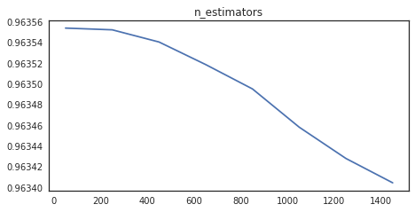

```python
import time
index = 1
plt.figure(figsize=(16,12))
start = time.time()
for parameter, param_range in dict.items(rf_param_grid):
    temp_time = time.time()
    print("parameter: {} start".format(parameter))
    plot, df, grid_search = evaluate_param(GBM, x_train, y_train, features, parameter, param_range, index)
    print("{} tunning time: {:.2f}".format(parameter, time.time() - temp_time))
    index += 1

print("total 6 feature tunning time : {:.2f}".format(time.time() - start))
```

```
parameter: n_estimators start
n_estimators tunning time: 60.95
total 6 feature tunning time : 60.95
```

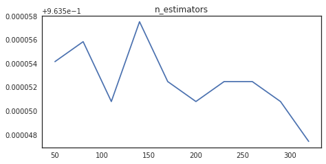

```python
rf_param_grid = {"n_estimators": np.arange(50, 350, 30)}

import time
index = 1
plt.figure(figsize=(16,12))
start = time.time()
for parameter, param_range in dict.items(rf_param_grid):
    temp_time = time.time()
    print("parameter: {} start".format(parameter))
    plot, df, grid_search = evaluate_param(GBM, x_train, y_train, features, parameter, param_range, index)
    print("{} tunning time: {:.2f}".format(parameter, (time.time() - temp_time)/60))
    index += 1

print("total 6 feature tunning time : {:.2f}".format((time.time() - start)/60))
```

```
parameter: n_estimators start
n_estimators tunning time: 25.15
total 6 feature tunning time : 25.15
```

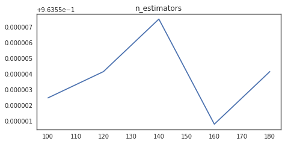

```python
rf_param_grid = {"n_estimators": np.arange(100, 200, 20)}

import time
index = 1
plt.figure(figsize=(16,12))
start = time.time()
for parameter, param_range in dict.items(rf_param_grid):
    temp_time = time.time()
    print("parameter: {} start".format(parameter))
    plot, df, grid_search = evaluate_param(GBM, x_train, y_train, features, parameter, param_range, index)
    print("{} tunning time: {:.2f}".format(parameter, (time.time() - temp_time)/60))
    index += 1

print("total 6 feature tunning time : {:.2f}".format((time.time() - start)/60))
```

```python
foo = pd.Series(grid_search.best_estimator_.feature_importances_, features)
```

```python
foo = foo.sort_values(ascending=False)
```

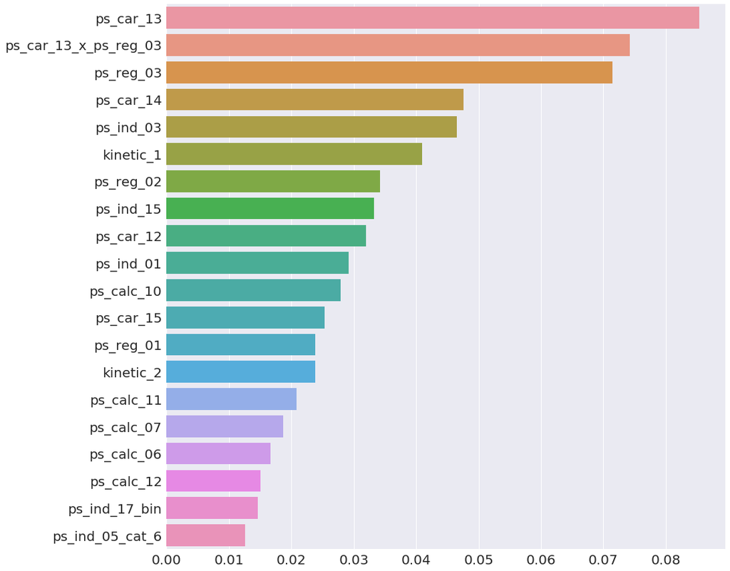

```python
fig, ax = plt.subplots(figsize=(15, 15))
sns.set(font_scale=3)
g = sns.barplot(foo[:20], foo.index[:20])
```

```python
def gsearch_function(model, param_grid):
    gsearch = GridSearchCV(model, param_grid=param_grid, scoring='roc_auc',
                           cv=kfold, verbose=10)
    start = time.time()
    print("Grid search start")
    gsearch.fit(x_train, y_train)
    print("total tunning time: {:.2f}".format((time.time() - start)/60))
    return gsearch
```

```python
GBM = GradientBoostingClassifier(learning_rate=0.1, n_estimators=140,
                                 max_depth=8,
                                 max_features='sqrt',subsample=0.8,
                                 random_state=1989)

## Search grid for optimal parameters

GBM_param_grid = {'max_depth':[7, 8, 9, 10, 11],
                  'min_samples_split':range(200,1001,200)}

gsearch1 = gsearch_function(GBM, param_grid=GBM_param_grid)

# for parameter, param_range in dict.items(GMB_param_grid):
#     temp_time = time.time()
#     print("parameter: {} start".format(parameter))
#     plot, df, grid_search = evaluate_param(GBM, x_train, y_train, features, parameter, param_range, index)
#     print("{} tunning time: {:.2f}".format(parameter, (time.time() - temp_time)/60))
#     index += 1

# print("total 6 feature tunning time : {:.2f}".format((time.time() - start)/60))
```

```
Grid search start
Fitting 3 folds for each of 25 candidates, totalling 75 fits
[CV] max_depth=7, min_samples_split=200 ..............................
[CV]  max_depth=7, min_samples_split=200, score=0.6374124819714562, total= 1.1min
[CV] max_depth=7, min_samples_split=200 ..............................
```

```
[Parallel(n_jobs=1)]: Done   1 out of   1 | elapsed:  1.2min remaining:    0.0s
```

```
[CV]  max_depth=7, min_samples_split=200, score=0.6382716914231861, total= 1.1min
[CV] max_depth=7, min_samples_split=200 ..............................
```

```
[Parallel(n_jobs=1)]: Done   2 out of   2 | elapsed:  2.3min remaining:    0.0s
```

```
[CV]  max_depth=7, min_samples_split=200, score=0.6330987587724425, total= 1.1min
[CV] max_depth=7, min_samples_split=400 ..............................
```

```
[Parallel(n_jobs=1)]: Done   3 out of   3 | elapsed:  3.5min remaining:    0.0s
```

```
[CV]  max_depth=7, min_samples_split=400, score=0.6383438332902289, total= 1.1min
[CV] max_depth=7, min_samples_split=400 ..............................
```

```
[Parallel(n_jobs=1)]: Done   4 out of   4 | elapsed:  4.6min remaining:    0.0s
```

```
[CV]  max_depth=7, min_samples_split=400, score=0.6376369505404964, total= 1.1min
[CV] max_depth=7, min_samples_split=400 ..............................
```

```
[Parallel(n_jobs=1)]: Done   5 out of   5 | elapsed:  5.8min remaining:    0.0s
```

```
[CV]  max_depth=7, min_samples_split=400, score=0.6353938802599602, total= 1.1min
[CV] max_depth=7, min_samples_split=600 ..............................
```

```
[Parallel(n_jobs=1)]: Done   6 out of   6 | elapsed:  6.9min remaining:    0.0s
```

```
[CV]  max_depth=7, min_samples_split=600, score=0.6385166275690429, total= 1.1min
[CV] max_depth=7, min_samples_split=600 ..............................
```

```
[Parallel(n_jobs=1)]: Done   7 out of   7 | elapsed:  8.0min remaining:    0.0s
```

```
[CV]  max_depth=7, min_samples_split=600, score=0.6388181521589498, total= 1.1min
[CV] max_depth=7, min_samples_split=600 ..............................
```

```
[Parallel(n_jobs=1)]: Done   8 out of   8 | elapsed:  9.1min remaining:    0.0s
```

```
[CV]  max_depth=7, min_samples_split=600, score=0.6353254916517936, total= 1.1min
[CV] max_depth=7, min_samples_split=800 ..............................
```

```
[Parallel(n_jobs=1)]: Done   9 out of   9 | elapsed: 10.2min remaining:    0.0s
```

```
[CV]  max_depth=7, min_samples_split=800, score=0.6391121186381754, total= 1.0min
[CV] max_depth=7, min_samples_split=800 ..............................
[CV]  max_depth=7, min_samples_split=800, score=0.639453495629092, total= 1.1min
[CV] max_depth=7, min_samples_split=800 ..............................
[CV]  max_depth=7, min_samples_split=800, score=0.6365863072380525, total= 1.1min
[CV] max_depth=7, min_samples_split=1000 .............................
[CV]  max_depth=7, min_samples_split=1000, score=0.6381822066750086, total= 1.0min
[CV] max_depth=7, min_samples_split=1000 .............................
[CV]  max_depth=7, min_samples_split=1000, score=0.639130317054904, total= 1.0min
[CV] max_depth=7, min_samples_split=1000 .............................
[CV]  max_depth=7, min_samples_split=1000, score=0.6375583452023428, total= 1.1min
[CV] max_depth=8, min_samples_split=200 ..............................
[CV]  max_depth=8, min_samples_split=200, score=0.6338936444780197, total= 1.4min
[CV] max_depth=8, min_samples_split=200 ..............................
[CV]  max_depth=8, min_samples_split=200, score=0.6365978459879976, total= 1.4min
[CV] max_depth=8, min_samples_split=200 ..............................
[CV]  max_depth=8, min_samples_split=200, score=0.6332505378182638, total= 1.4min
[CV] max_depth=8, min_samples_split=400 ..............................
[CV]  max_depth=8, min_samples_split=400, score=0.6353527264884343, total= 1.3min
[CV] max_depth=8, min_samples_split=400 ..............................
[CV]  max_depth=8, min_samples_split=400, score=0.6374324469715826, total= 1.4min
[CV] max_depth=8, min_samples_split=400 ..............................
[CV]  max_depth=8, min_samples_split=400, score=0.6330759652221799, total= 1.4min
[CV] max_depth=8, min_samples_split=600 ..............................
[CV]  max_depth=8, min_samples_split=600, score=0.6363726618268519, total= 1.3min
[CV] max_depth=8, min_samples_split=600 ..............................
[CV]  max_depth=8, min_samples_split=600, score=0.6383243805704992, total= 1.3min
[CV] max_depth=8, min_samples_split=600 ..............................
[CV]  max_depth=8, min_samples_split=600, score=0.6340445265352733, total= 1.3min
[CV] max_depth=8, min_samples_split=800 ..............................
[CV]  max_depth=8, min_samples_split=800, score=0.636479873567235, total= 1.3min
[CV] max_depth=8, min_samples_split=800 ..............................
[CV]  max_depth=8, min_samples_split=800, score=0.637570485795508, total= 1.3min
[CV] max_depth=8, min_samples_split=800 ..............................
[CV]  max_depth=8, min_samples_split=800, score=0.6345685655122746, total= 1.3min
[CV] max_depth=8, min_samples_split=1000 .............................
[CV]  max_depth=8, min_samples_split=1000, score=0.6385105569601994, total= 1.2min
[CV] max_depth=8, min_samples_split=1000 .............................
[CV]  max_depth=8, min_samples_split=1000, score=0.6382636899588219, total= 1.2min
[CV] max_depth=8, min_samples_split=1000 .............................
```

[output cut: 76 more lines]

```
[CV]  max_depth=11, min_samples_split=600, score=0.6307467008429193, total= 2.1min
[CV] max_depth=11, min_samples_split=600 .............................
[CV]  max_depth=11, min_samples_split=600, score=0.6265412339816552, total= 2.1min
[CV] max_depth=11, min_samples_split=800 .............................
[CV]  max_depth=11, min_samples_split=800, score=0.632784320816724, total= 2.0min
[CV] max_depth=11, min_samples_split=800 .............................
[CV]  max_depth=11, min_samples_split=800, score=0.6315395156780969, total= 2.0min
[CV] max_depth=11, min_samples_split=800 .............................
[CV]  max_depth=11, min_samples_split=800, score=0.6301017161656002, total= 2.1min
[CV] max_depth=11, min_samples_split=1000 ............................
[CV]  max_depth=11, min_samples_split=1000, score=0.6288202363873818, total= 2.0min
[CV] max_depth=11, min_samples_split=1000 ............................
[CV]  max_depth=11, min_samples_split=1000, score=0.6324878320756278, total= 2.0min
[CV] max_depth=11, min_samples_split=1000 ............................
[CV]  max_depth=11, min_samples_split=1000, score=0.6308246375313342, total= 2.0min
```

```
[Parallel(n_jobs=1)]: Done  75 out of  75 | elapsed: 123.4min finished
```

```
total tunning time: 125.12
```

```
Text(60,0.5,'min_samples_split')
```

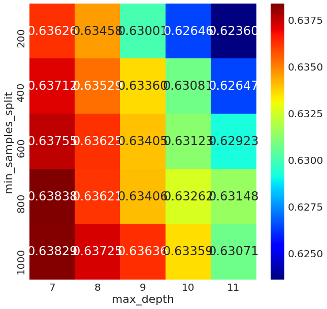

```python
# array 만들땐, quick 이 먼저. (quick, slow)
results = pd.DataFrame(gsearch1.cv_results_)
slow = 'max_depth'
quick = 'min_samples_split'
scores = np.array(results['mean_test_score']).reshape(len(GBM_param_grid[slow]), len(GBM_param_grid[quick])).T

fig, ax = plt.subplots(figsize=(10, 10))
sns.set(font_scale=2)
g = sns.heatmap(scores, xticklabels=GBM_param_grid[slow],
           yticklabels=GBM_param_grid[quick],
           annot=True, fmt='.5f', cmap='jet')
g.set_xlabel(slow)
g.set_ylabel(quick)
```

```python
GBM = GradientBoostingClassifier(learning_rate=0.1, n_estimators=140,
                                 max_depth=8,
                                 max_features='sqrt',subsample=0.8,
                                 random_state=1989)

## Search grid for optimal parameters

GBM_param_grid = {'max_depth':[6, 7, 8],
                  'min_samples_split':[700, 750, 800, 850, 900]}

gsearch1 = gsearch_function(GBM, param_grid=GBM_param_grid)

# for parameter, param_range in dict.items(GMB_param_grid):
#     temp_time = time.time()
#     print("parameter: {} start".format(parameter))
#     plot, df, grid_search = evaluate_param(GBM, x_train, y_train, features, parameter, param_range, index)
#     print("{} tunning time: {:.2f}".format(parameter, (time.time() - temp_time)/60))
#     index += 1

# print("total 6 feature tunning time : {:.2f}".format((time.time() - start)/60))
```

```
Grid search start
Fitting 3 folds for each of 15 candidates, totalling 45 fits
[CV] max_depth=6, min_samples_split=700 ..............................
[CV]  max_depth=6, min_samples_split=700, score=0.6388595818889243, total=  53.0s
[CV] max_depth=6, min_samples_split=700 ..............................
```

```
[Parallel(n_jobs=1)]: Done   1 out of   1 | elapsed:   54.7s remaining:    0.0s
```

```
[CV]  max_depth=6, min_samples_split=700, score=0.639694296953851, total=  52.0s
[CV] max_depth=6, min_samples_split=700 ..............................
```

```
[Parallel(n_jobs=1)]: Done   2 out of   2 | elapsed:  1.8min remaining:    0.0s
```

```
[CV]  max_depth=6, min_samples_split=700, score=0.6369074164140351, total=  52.0s
[CV] max_depth=6, min_samples_split=750 ..............................
```

```
[Parallel(n_jobs=1)]: Done   3 out of   3 | elapsed:  2.7min remaining:    0.0s
```

```
[CV]  max_depth=6, min_samples_split=750, score=0.6384965612159935, total=  52.6s
[CV] max_depth=6, min_samples_split=750 ..............................
```

```
[Parallel(n_jobs=1)]: Done   4 out of   4 | elapsed:  3.6min remaining:    0.0s
```

```
[CV]  max_depth=6, min_samples_split=750, score=0.6388733825904426, total=  52.4s
[CV] max_depth=6, min_samples_split=750 ..............................
```

```
[Parallel(n_jobs=1)]: Done   5 out of   5 | elapsed:  4.5min remaining:    0.0s
```

```
[CV]  max_depth=6, min_samples_split=750, score=0.6361857154208705, total=  52.4s
[CV] max_depth=6, min_samples_split=800 ..............................
```

```
[Parallel(n_jobs=1)]: Done   6 out of   6 | elapsed:  5.4min remaining:    0.0s
```

```
[CV]  max_depth=6, min_samples_split=800, score=0.6394572768357104, total=  52.0s
[CV] max_depth=6, min_samples_split=800 ..............................
```

```
[Parallel(n_jobs=1)]: Done   7 out of   7 | elapsed:  6.3min remaining:    0.0s
```

```
[CV]  max_depth=6, min_samples_split=800, score=0.63925055314508, total=  52.1s
[CV] max_depth=6, min_samples_split=800 ..............................
```

```
[Parallel(n_jobs=1)]: Done   8 out of   8 | elapsed:  7.2min remaining:    0.0s
```

```
[CV]  max_depth=6, min_samples_split=800, score=0.6363115309860206, total=  52.1s
[CV] max_depth=6, min_samples_split=850 ..............................
```

```
[Parallel(n_jobs=1)]: Done   9 out of   9 | elapsed:  8.1min remaining:    0.0s
```

```
[CV]  max_depth=6, min_samples_split=850, score=0.6378422214781228, total=  52.3s
[CV] max_depth=6, min_samples_split=850 ..............................
[CV]  max_depth=6, min_samples_split=850, score=0.6398134219103806, total=  51.4s
[CV] max_depth=6, min_samples_split=850 ..............................
[CV]  max_depth=6, min_samples_split=850, score=0.6367434372595091, total=  52.1s
[CV] max_depth=6, min_samples_split=900 ..............................
[CV]  max_depth=6, min_samples_split=900, score=0.6387095185792658, total=  52.0s
[CV] max_depth=6, min_samples_split=900 ..............................
[CV]  max_depth=6, min_samples_split=900, score=0.6387685374374161, total=  52.1s
[CV] max_depth=6, min_samples_split=900 ..............................
[CV]  max_depth=6, min_samples_split=900, score=0.6364968757029892, total=  52.0s
[CV] max_depth=7, min_samples_split=700 ..............................
[CV]  max_depth=7, min_samples_split=700, score=0.6384820114283736, total= 1.1min
[CV] max_depth=7, min_samples_split=700 ..............................
[CV]  max_depth=7, min_samples_split=700, score=0.6408227602341787, total= 1.1min
[CV] max_depth=7, min_samples_split=700 ..............................
[CV]  max_depth=7, min_samples_split=700, score=0.635461777680827, total= 1.1min
[CV] max_depth=7, min_samples_split=750 ..............................
[CV]  max_depth=7, min_samples_split=750, score=0.6384755307116767, total= 1.1min
[CV] max_depth=7, min_samples_split=750 ..............................
[CV]  max_depth=7, min_samples_split=750, score=0.6386313637930748, total= 1.1min
[CV] max_depth=7, min_samples_split=750 ..............................
[CV]  max_depth=7, min_samples_split=750, score=0.6364493535125866, total= 1.1min
[CV] max_depth=7, min_samples_split=800 ..............................
[CV]  max_depth=7, min_samples_split=800, score=0.6391121186381754, total= 1.1min
[CV] max_depth=7, min_samples_split=800 ..............................
[CV]  max_depth=7, min_samples_split=800, score=0.639453495629092, total= 1.1min
[CV] max_depth=7, min_samples_split=800 ..............................
[CV]  max_depth=7, min_samples_split=800, score=0.6365863072380525, total= 1.1min
[CV] max_depth=7, min_samples_split=850 ..............................
[CV]  max_depth=7, min_samples_split=850, score=0.6380492131102213, total= 1.1min
[CV] max_depth=7, min_samples_split=850 ..............................
[CV]  max_depth=7, min_samples_split=850, score=0.6389120407818919, total= 1.1min
[CV] max_depth=7, min_samples_split=850 ..............................
[CV]  max_depth=7, min_samples_split=850, score=0.6349288018438827, total= 1.1min
[CV] max_depth=7, min_samples_split=900 ..............................
[CV]  max_depth=7, min_samples_split=900, score=0.639003563017031, total= 1.1min
[CV] max_depth=7, min_samples_split=900 ..............................
[CV]  max_depth=7, min_samples_split=900, score=0.6386346610242991, total= 1.0min
[CV] max_depth=7, min_samples_split=900 ..............................
```

[output cut: 16 more lines]

```
[CV]  max_depth=8, min_samples_split=800, score=0.637570485795508, total= 1.3min
[CV] max_depth=8, min_samples_split=800 ..............................
[CV]  max_depth=8, min_samples_split=800, score=0.6345685655122746, total= 1.3min
[CV] max_depth=8, min_samples_split=850 ..............................
[CV]  max_depth=8, min_samples_split=850, score=0.637270799472553, total= 1.3min
[CV] max_depth=8, min_samples_split=850 ..............................
[CV]  max_depth=8, min_samples_split=850, score=0.6373215383275247, total= 1.3min
[CV] max_depth=8, min_samples_split=850 ..............................
[CV]  max_depth=8, min_samples_split=850, score=0.6348330601073233, total= 1.3min
[CV] max_depth=8, min_samples_split=900 ..............................
[CV]  max_depth=8, min_samples_split=900, score=0.6370793355219331, total= 1.3min
[CV] max_depth=8, min_samples_split=900 ..............................
[CV]  max_depth=8, min_samples_split=900, score=0.6393761271618036, total= 1.3min
[CV] max_depth=8, min_samples_split=900 ..............................
[CV]  max_depth=8, min_samples_split=900, score=0.6349606762103072, total= 1.3min
```

```
[Parallel(n_jobs=1)]: Done  45 out of  45 | elapsed: 49.5min finished
```

```
total tunning time: 50.96
```

```
Text(60,0.5,'min_samples_split')
```

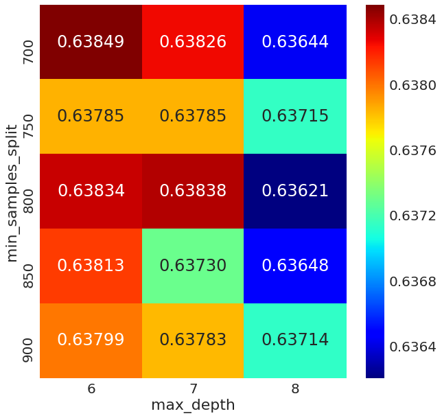

```python
# array 만들땐, quick 이 먼저. (quick, slow)
results = pd.DataFrame(gsearch1.cv_results_)
slow = 'max_depth'
quick = 'min_samples_split'
scores = np.array(results['mean_test_score']).reshape(len(GBM_param_grid[slow]), len(GBM_param_grid[quick])).T

fig, ax = plt.subplots(figsize=(10, 10))
sns.set(font_scale=2)
g = sns.heatmap(scores, xticklabels=GBM_param_grid[slow],
           yticklabels=GBM_param_grid[quick],
           annot=True, fmt='.5f', cmap='jet')
g.set_xlabel(slow)
g.set_ylabel(quick)
```

```python
GBM = GradientBoostingClassifier(learning_rate=0.1, n_estimators=140,
                                 max_depth=8,
                                 max_features='sqrt',subsample=0.8,
                                 random_state=1989)

## Search grid for optimal parameters

GBM_param_grid = {'max_depth':[5, 6],
                  'min_samples_split':[600, 630, 660, 690, 720]}

gsearch1 = gsearch_function(GBM, param_grid=GBM_param_grid)

# for parameter, param_range in dict.items(GMB_param_grid):
#     temp_time = time.time()
#     print("parameter: {} start".format(parameter))
#     plot, df, grid_search = evaluate_param(GBM, x_train, y_train, features, parameter, param_range, index)
#     print("{} tunning time: {:.2f}".format(parameter, (time.time() - temp_time)/60))
#     index += 1

# print("total 6 feature tunning time : {:.2f}".format((time.time() - start)/60))
```

```
Grid search start
Fitting 3 folds for each of 10 candidates, totalling 30 fits
[CV] max_depth=5, min_samples_split=600 ..............................
[CV]  max_depth=5, min_samples_split=600, score=0.6391148440110007, total=  42.4s
[CV] max_depth=5, min_samples_split=600 ..............................
```

```
[Parallel(n_jobs=1)]: Done   1 out of   1 | elapsed:   44.1s remaining:    0.0s
```

```
[CV]  max_depth=5, min_samples_split=600, score=0.6391893482000546, total=  42.2s
[CV] max_depth=5, min_samples_split=600 ..............................
```

```
[Parallel(n_jobs=1)]: Done   2 out of   2 | elapsed:  1.5min remaining:    0.0s
```

```
[CV]  max_depth=5, min_samples_split=600, score=0.6364420934894047, total=  42.1s
[CV] max_depth=5, min_samples_split=630 ..............................
```

```
[Parallel(n_jobs=1)]: Done   3 out of   3 | elapsed:  2.2min remaining:    0.0s
```

```
[CV]  max_depth=5, min_samples_split=630, score=0.6393589464257204, total=  42.3s
[CV] max_depth=5, min_samples_split=630 ..............................
```

```
[Parallel(n_jobs=1)]: Done   4 out of   4 | elapsed:  2.9min remaining:    0.0s
```

```
[CV]  max_depth=5, min_samples_split=630, score=0.638913727737402, total=  42.2s
[CV] max_depth=5, min_samples_split=630 ..............................
```

```
[Parallel(n_jobs=1)]: Done   5 out of   5 | elapsed:  3.7min remaining:    0.0s
```

```
[CV]  max_depth=5, min_samples_split=630, score=0.6357474323932623, total=  41.8s
[CV] max_depth=5, min_samples_split=660 ..............................
```

```
[Parallel(n_jobs=1)]: Done   6 out of   6 | elapsed:  4.4min remaining:    0.0s
```

```
[CV]  max_depth=5, min_samples_split=660, score=0.6397549659533234, total=  41.9s
[CV] max_depth=5, min_samples_split=660 ..............................
```

```
[Parallel(n_jobs=1)]: Done   7 out of   7 | elapsed:  5.1min remaining:    0.0s
```

```
[CV]  max_depth=5, min_samples_split=660, score=0.6392109715408052, total=  42.4s
[CV] max_depth=5, min_samples_split=660 ..............................
```

```
[Parallel(n_jobs=1)]: Done   8 out of   8 | elapsed:  5.8min remaining:    0.0s
```

```
[CV]  max_depth=5, min_samples_split=660, score=0.6355896701218793, total=  41.8s
[CV] max_depth=5, min_samples_split=690 ..............................
```

```
[Parallel(n_jobs=1)]: Done   9 out of   9 | elapsed:  6.6min remaining:    0.0s
```

```
[CV]  max_depth=5, min_samples_split=690, score=0.6387203665467904, total=  42.1s
[CV] max_depth=5, min_samples_split=690 ..............................
[CV]  max_depth=5, min_samples_split=690, score=0.6394705189054822, total=  42.0s
[CV] max_depth=5, min_samples_split=690 ..............................
[CV]  max_depth=5, min_samples_split=690, score=0.6360752257675509, total=  42.1s
[CV] max_depth=5, min_samples_split=720 ..............................
[CV]  max_depth=5, min_samples_split=720, score=0.6383308921090747, total=  42.0s
[CV] max_depth=5, min_samples_split=720 ..............................
[CV]  max_depth=5, min_samples_split=720, score=0.6396305485544631, total=  42.0s
[CV] max_depth=5, min_samples_split=720 ..............................
[CV]  max_depth=5, min_samples_split=720, score=0.6355670429531763, total=  41.4s
[CV] max_depth=6, min_samples_split=600 ..............................
[CV]  max_depth=6, min_samples_split=600, score=0.6399684867628352, total=  53.2s
[CV] max_depth=6, min_samples_split=600 ..............................
[CV]  max_depth=6, min_samples_split=600, score=0.6388779855483802, total=  53.7s
[CV] max_depth=6, min_samples_split=600 ..............................
[CV]  max_depth=6, min_samples_split=600, score=0.6374499186803617, total=  52.6s
[CV] max_depth=6, min_samples_split=630 ..............................
[CV]  max_depth=6, min_samples_split=630, score=0.6382449727055358, total=  52.9s
[CV] max_depth=6, min_samples_split=630 ..............................
[CV]  max_depth=6, min_samples_split=630, score=0.6399561367550681, total=  53.9s
[CV] max_depth=6, min_samples_split=630 ..............................
[CV]  max_depth=6, min_samples_split=630, score=0.635940949338398, total=  52.8s
[CV] max_depth=6, min_samples_split=660 ..............................
[CV]  max_depth=6, min_samples_split=660, score=0.6382158261161681, total=  52.4s
[CV] max_depth=6, min_samples_split=660 ..............................
[CV]  max_depth=6, min_samples_split=660, score=0.6392864385661734, total=  53.4s
[CV] max_depth=6, min_samples_split=660 ..............................
[CV]  max_depth=6, min_samples_split=660, score=0.6373669304520422, total=  52.7s
[CV] max_depth=6, min_samples_split=690 ..............................
[CV]  max_depth=6, min_samples_split=690, score=0.6385981992506995, total=  52.9s
[CV] max_depth=6, min_samples_split=690 ..............................
[CV]  max_depth=6, min_samples_split=690, score=0.6392005593649326, total=  53.3s
[CV] max_depth=6, min_samples_split=690 ..............................
[CV]  max_depth=6, min_samples_split=690, score=0.63723097646273, total=  53.2s
[CV] max_depth=6, min_samples_split=720 ..............................
[CV]  max_depth=6, min_samples_split=720, score=0.6389550480535885, total=  53.2s
[CV] max_depth=6, min_samples_split=720 ..............................
[CV]  max_depth=6, min_samples_split=720, score=0.6395493576716877, total=  52.7s
[CV] max_depth=6, min_samples_split=720 ..............................
[CV]  max_depth=6, min_samples_split=720, score=0.6373653519974206, total=  52.3s
```

```
[Parallel(n_jobs=1)]: Done  30 out of  30 | elapsed: 24.6min finished
```

```
total tunning time: 26.08
```

```
Text(60,0.5,'min_samples_split')
```

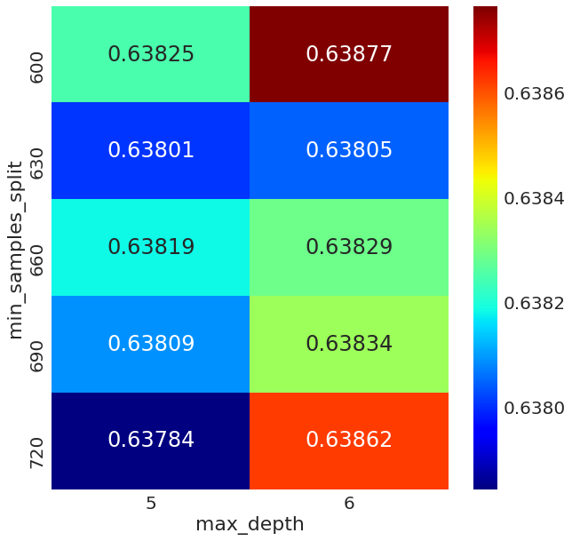

```python
# array 만들땐, quick 이 먼저. (quick, slow)
results = pd.DataFrame(gsearch1.cv_results_)
slow = 'max_depth'
quick = 'min_samples_split'
scores = np.array(results['mean_test_score']).reshape(len(GBM_param_grid[slow]), len(GBM_param_grid[quick])).T

fig, ax = plt.subplots(figsize=(10, 10))
sns.set(font_scale=2)
g = sns.heatmap(scores, xticklabels=GBM_param_grid[slow],
           yticklabels=GBM_param_grid[quick],
           annot=True, fmt='.5f', cmap='jet')
g.set_xlabel(slow)
g.set_ylabel(quick)
```

```python
GBM = GradientBoostingClassifier(learning_rate=0.1, n_estimators=140,
                                 max_depth=6, min_samples_split=600,
                                 max_features='sqrt',subsample=0.8,
                                 random_state=1989)

## Search grid for optimal parameters

GBM_param_grid = {'min_samples_leaf':range(30,71,10)}
gsearch1 = gsearch_function(GBM, param_grid=GBM_param_grid)

# for parameter, param_range in dict.items(GMB_param_grid):
#     temp_time = time.time()
#     print("parameter: {} start".format(parameter))
#     plot, df, grid_search = evaluate_param(GBM, x_train, y_train, features, parameter, param_range, index)
#     print("{} tunning time: {:.2f}".format(parameter, (time.time() - temp_time)/60))
#     index += 1

# print("total 6 feature tunning time : {:.2f}".format((time.time() - start)/60))
```

```
Grid search start
Fitting 3 folds for each of 5 candidates, totalling 15 fits
[CV] min_samples_leaf=30 .............................................
[CV] .... min_samples_leaf=30, score=0.6366022260266602, total=  53.1s
[CV] min_samples_leaf=30 .............................................
```

```
[Parallel(n_jobs=1)]: Done   1 out of   1 | elapsed:   54.9s remaining:    0.0s
```

```
[CV] .... min_samples_leaf=30, score=0.6398528541337323, total=  53.6s
[CV] min_samples_leaf=30 .............................................
```

```
[Parallel(n_jobs=1)]: Done   2 out of   2 | elapsed:  1.8min remaining:    0.0s
```

```
[CV] .... min_samples_leaf=30, score=0.6373293238791917, total=  53.6s
[CV] min_samples_leaf=40 .............................................
```

```
[Parallel(n_jobs=1)]: Done   3 out of   3 | elapsed:  2.8min remaining:    0.0s
```

```
[CV] .... min_samples_leaf=40, score=0.6375758264105778, total=  53.5s
[CV] min_samples_leaf=40 .............................................
```

```
[Parallel(n_jobs=1)]: Done   4 out of   4 | elapsed:  3.7min remaining:    0.0s
```

```
[CV] .... min_samples_leaf=40, score=0.6398356981144879, total=  53.7s
[CV] min_samples_leaf=40 .............................................
```

```
[Parallel(n_jobs=1)]: Done   5 out of   5 | elapsed:  4.6min remaining:    0.0s
```

```
[CV] .... min_samples_leaf=40, score=0.6373849756172743, total=  53.5s
[CV] min_samples_leaf=50 .............................................
```

```
[Parallel(n_jobs=1)]: Done   6 out of   6 | elapsed:  5.5min remaining:    0.0s
```

```
[CV] .... min_samples_leaf=50, score=0.6385072746507832, total=  54.2s
[CV] min_samples_leaf=50 .............................................
```

```
[Parallel(n_jobs=1)]: Done   7 out of   7 | elapsed:  6.5min remaining:    0.0s
```

```
[CV] .... min_samples_leaf=50, score=0.6408330837942493, total=  54.3s
[CV] min_samples_leaf=50 .............................................
```

```
[Parallel(n_jobs=1)]: Done   8 out of   8 | elapsed:  7.4min remaining:    0.0s
```

```
[CV] .... min_samples_leaf=50, score=0.6358257518103406, total=  53.8s
[CV] min_samples_leaf=60 .............................................
```

```
[Parallel(n_jobs=1)]: Done   9 out of   9 | elapsed:  8.3min remaining:    0.0s
```

```
[CV] .... min_samples_leaf=60, score=0.6392959142229003, total=  53.5s
[CV] min_samples_leaf=60 .............................................
[CV] .... min_samples_leaf=60, score=0.6387346927116461, total=  53.6s
[CV] min_samples_leaf=60 .............................................
[CV] .... min_samples_leaf=60, score=0.6385329461660485, total=  53.5s
[CV] min_samples_leaf=70 .............................................
[CV] .... min_samples_leaf=70, score=0.6383853872695764, total=  54.1s
[CV] min_samples_leaf=70 .............................................
[CV] .... min_samples_leaf=70, score=0.6391241920753568, total=  53.9s
[CV] min_samples_leaf=70 .............................................
[CV] .... min_samples_leaf=70, score=0.6363881504175991, total=  54.2s
```

```
[Parallel(n_jobs=1)]: Done  15 out of  15 | elapsed: 13.9min finished
```

```
total tunning time: 15.32
```

```python
GBM = GradientBoostingClassifier(learning_rate=0.1, n_estimators=140,
                                 max_depth=8,
                                 max_features='sqrt',subsample=0.8,
                                 random_state=1989)

## Search grid for optimal parameters

GBM_param_grid = {'max_depth':[5, 6, 7, 8, 9, 10, 11],
                  'min_samples_split':[600, 650, 700, 750, 800, 850, 900]}

gsearch_test = gsearch_function(GBM, param_grid=GBM_param_grid)

# for parameter, param_range in dict.items(GMB_param_grid):
#     temp_time = time.time()
#     print("parameter: {} start".format(parameter))
#     plot, df, grid_search = evaluate_param(GBM, x_train, y_train, features, parameter, param_range, index)
#     print("{} tunning time: {:.2f}".format(parameter, (time.time() - temp_time)/60))
#     index += 1

# print("total 6 feature tunning time : {:.2f}".format((time.time() - start)/60))
```

```
Grid search start
Fitting 3 folds for each of 49 candidates, totalling 147 fits
[CV] max_depth=5, min_samples_split=600 ..............................
[CV]  max_depth=5, min_samples_split=600, score=0.6391148440110007, total=  42.3s
[CV] max_depth=5, min_samples_split=600 ..............................
```

```
[Parallel(n_jobs=1)]: Done   1 out of   1 | elapsed:   44.0s remaining:    0.0s
```

```
[CV]  max_depth=5, min_samples_split=600, score=0.6391893482000546, total=  42.2s
[CV] max_depth=5, min_samples_split=600 ..............................
```

```
[Parallel(n_jobs=1)]: Done   2 out of   2 | elapsed:  1.5min remaining:    0.0s
```

```
[CV]  max_depth=5, min_samples_split=600, score=0.6364420934894047, total=  42.2s
[CV] max_depth=5, min_samples_split=650 ..............................
```

```
[Parallel(n_jobs=1)]: Done   3 out of   3 | elapsed:  2.2min remaining:    0.0s
```

```
[CV]  max_depth=5, min_samples_split=650, score=0.6393853155650752, total=  42.1s
[CV] max_depth=5, min_samples_split=650 ..............................
```

```
[Parallel(n_jobs=1)]: Done   4 out of   4 | elapsed:  2.9min remaining:    0.0s
```

```
[CV]  max_depth=5, min_samples_split=650, score=0.6395441720196404, total=  42.4s
[CV] max_depth=5, min_samples_split=650 ..............................
```

```
[Parallel(n_jobs=1)]: Done   5 out of   5 | elapsed:  3.7min remaining:    0.0s
```

```
[CV]  max_depth=5, min_samples_split=650, score=0.6356271414192879, total=  41.7s
[CV] max_depth=5, min_samples_split=700 ..............................
```

```
[Parallel(n_jobs=1)]: Done   6 out of   6 | elapsed:  4.4min remaining:    0.0s
```

```
[CV]  max_depth=5, min_samples_split=700, score=0.6388825363560106, total=  42.1s
[CV] max_depth=5, min_samples_split=700 ..............................
```

```
[Parallel(n_jobs=1)]: Done   7 out of   7 | elapsed:  5.1min remaining:    0.0s
```

```
[CV]  max_depth=5, min_samples_split=700, score=0.6394134054786237, total=  42.1s
[CV] max_depth=5, min_samples_split=700 ..............................
```

```
[Parallel(n_jobs=1)]: Done   8 out of   8 | elapsed:  5.8min remaining:    0.0s
```

```
[CV]  max_depth=5, min_samples_split=700, score=0.6362605335912173, total=  41.4s
[CV] max_depth=5, min_samples_split=750 ..............................
```

```
[Parallel(n_jobs=1)]: Done   9 out of   9 | elapsed:  6.6min remaining:    0.0s
```

```
[CV]  max_depth=5, min_samples_split=750, score=0.6392375436516774, total=  41.9s
[CV] max_depth=5, min_samples_split=750 ..............................
[CV]  max_depth=5, min_samples_split=750, score=0.6405405662875122, total=  41.6s
[CV] max_depth=5, min_samples_split=750 ..............................
[CV]  max_depth=5, min_samples_split=750, score=0.6362517428576875, total=  41.6s
[CV] max_depth=5, min_samples_split=800 ..............................
[CV]  max_depth=5, min_samples_split=800, score=0.6385990346555862, total=  41.9s
[CV] max_depth=5, min_samples_split=800 ..............................
```

from operator import itemgetter

# Utility function to report best scores

RFC_final = RandomForestClassifier(max_depth=3, n_estimators=240, min_samples_leaf=20, min_weight_fraction_leaf=0.1, max_leaf_nodes=10, min_samples_split=20)

RFC_final.fit(x_train, y_train)

prediction = RFC_final.predict_proba(x_test)

prediction[:, 1].shape

sub['target'] = prediction[:, 1]

sub.to_csv('wow.csv', index=False)

import matplotlib.pyplot as plt

[output not shown]

```python
# Gradient boosting tunning

GBC = GradientBoostingClassifier()
gb_param_grid = {'loss' : ["deviance"],
              'n_estimators' : [100,200,300],
              'learning_rate': [0.1, 0.05, 0.01],
              'max_depth': [4, 8],
              'min_samples_leaf': [100,150],
              'max_features': [0.3, 0.1]
              }

gsGBC = GridSearchCV(GBC,param_grid = gb_param_grid, cv=kfold, scoring="accuracy", n_jobs= 4, verbose = 1)

gsGBC.fit(x_train,y_train)

GBC_best = gsGBC.best_estimator_

# Best score
gsGBC.best_score_
```

names_classifiers = [("AdaBoosting", ada_best),("ExtraTrees",ExtC_best),("RandomForest",RFC_best),("GradientBoosting",GBC_best)]

fig.savefig('output6.png')

# Concatenate all classifier results

ensemble_results = pd.concat([test_Survived_RFC,test_Survived_ExtC,test_Survived_AdaC,test_Survived_GBC, test_Survived_SVMC],axis=1)

votingC = VotingClassifier(estimators=[('rfc', RFC_best), ('extc', ExtC_best), ('svc', SVMC_best), ('adac',ada_best),('gbc',GBC_best)], voting='soft', n_jobs=4)

votingC = votingC.fit(x_train, y_train)

test_Survived = pd.Series(votingC.predict_proba(test2)[:, 1], name="target")

results = pd.concat([test['id'],test_Survived],axis=1)

results.to_csv("ensemble_python_voting.csv",index=False)

```python
# for i, (train_index, test_index) in enumerate(skf.split(X, y)):
#     print(' xgb kfold: {}  of  {} : '.format(i+1, kfold))
#     X_train, X_valid = X[train_index], X[test_index]
#     y_train, y_valid = y[train_index], y[test_index]
#     d_train = xgb.DMatrix(X_train, y_train)
#     d_valid = xgb.DMatrix(X_valid, y_valid)
#     watchlist = [(d_train, 'train'), (d_valid, 'valid')]
#     xgb_model = xgb.train(params, d_train, nrounds, watchlist, early_stopping_rounds=100,
#                           feval=gini_xgb, maximize=True, verbose_eval=100)
#     sub['target'] += xgb_model.predict(xgb.DMatrix(test[features].values),
#                         ntree_limit=xgb_model.best_ntree_limit+50) / (kfold)
# sub.head(2)
```

```python
# sub2=test['id'].to_frame()
# sub2['target']=0

# nrounds=2000
# kfold = 5
# skf = StratifiedKFold(n_splits=kfold, random_state=0)

# for i, (train_index, test_index) in enumerate(skf.split(X, y)):
#     print(' xgb kfold: {}  of  {} : '.format(i+1, kfold))
#     X_train, X_valid = X[train_index], X[test_index]
#     y_train, y_valid = y[train_index], y[test_index]
#     d_train = xgb.DMatrix(X_train, y_train)
#     d_valid = xgb.DMatrix(X_valid, y_valid)
#     watchlist = [(d_train, 'train'), (d_valid, 'valid')]
#     xgb_model = xgb.train(params, d_train, nrounds, watchlist, early_stopping_rounds=100,
#                           feval=gini_xgb, maximize=True, verbose_eval=100)
#     sub2['target'] += xgb_model.predict(xgb.DMatrix(test[features].values),
#                         ntree_limit=xgb_model.best_ntree_limit+50) / (2*kfold)
# sub.head(2)
```

```python
# # lgb
# params = {'metric': 'auc', 'learning_rate' : 0.01, 'max_depth':10, 'max_bin':10,  'objective': 'binary',
#           'feature_fraction': 0.8,'bagging_fraction':0.9,'bagging_freq':10,  'min_data': 500}

# skf = StratifiedKFold(n_splits=kfold, random_state=1)
# for i, (train_index, test_index) in enumerate(skf.split(X, y)):
#     print(' lgb kfold: {}  of  {} : '.format(i+1, kfold))
#     X_train, X_eval = X[train_index], X[test_index]
#     y_train, y_eval = y[train_index], y[test_index]
#     lgb_model = lgb.train(params, lgb.Dataset(X_train, label=y_train), nrounds,
#                   lgb.Dataset(X_eval, label=y_eval), verbose_eval=100,
#                   feval=gini_lgb, early_stopping_rounds=100)
#     foo = lgb_model.predict(test[features].values, num_iteration=lgb_model.best_iteration)
#     sub['target'] += foo / (2*kfold)
```

```python
# # sub.to_csv('sub10.csv', index=False, float_format='%.5f')
# sub.to_csv('youhan_20.csv', index=False)
```

```python
# sub2.to_csv('sub121.csv', index=False, float_format='%.5f')
```